# Lösung: Einführung in Numpy

## Modul: Lineare Algebra und Geometrie (lag)

**Ziel der Übung**

Ziel dieser Programmierübung ist es, erste Gehversuche mit Python und Jupiter Notebooks zu machen. Daneben behandeln die Aufgaben der Übung mathematische Themen aus der Vorlesung. Diese Übung wird weder bewertet noch korrigiert und dient als Vorbereitung auf die bewerteten Programmierübungen. **Nur wenn Sie diese Programmierübung gewissenhaft lösen und selbst mit der nachträglich verteilten Lösung korrigieren, können Sie die erste bewertete Programmierübung in vernünftiger Zeit lösen.**

In den späteren, bewerteten Übungen müssen Sie alles vervollständigen, wo entweder # IHR CODE oder # Ihre Kommentare in Markdown steht. Ihre Antworten werden dann korrigiert und entsprechend bewertet. Sie werden die bewerteten Übungen später per Email abgeben. Beachten Sie, dass dazu nur dieses Notebook-File (Erweiterung .ipynb) gesendet werden muss.

- Bei der ersten Aufgabe geht es um das Erstellen von Matrizen in Python. Dabei sind für die einzelnen Elemente Berechnungsvorschriften gegeben, welche an bestimmte Bedingungen geknüpft sind. Hier sollen Sie mittels for-Schleifen über alle Elemente iterieren und mit bedingten Strukturen (if) die korrekte Berechnungsvorschrift anwenden. Hauptziel ist hier sicherlich die Verwendung der Programmierstrukturen in der Programmiersprache Python.
- Bei der zweiten Aufgabe werden Matrizen als Datenbehälter für die Umsatzzahlen einer Ladenkette verwendet. Mittels der Rechenoperationen mit Matrizen lassen sich nun die in den Matrizen gespeicherten Daten weiter verarbeiten. Ein zentrales Ziel ist es, das Verständnis für die Matrizenmultiplikation zu vertiefen.
- Die dritte Aufgabe widmet sich sogenannten *Markov-Prozessen* und ist deutlich anspruchsvoller als die ersten zwei. In dieser Aufgabe soll das Verständnis für die Matrixmultiplikation vertieft werden und deutlich werden, dass auch Wahrscheinlichkeitsprozesse mit Matrizen modelliert werden können (Matrizen sind allgegenwärtig!).

Sie dürfen in dieses Notebook über den Menüpunkt 'Insert' durchaus weitere Zeilen einfügen. Falls Sie gerne Markdown-Notizen in die Zelle einfügen möchten, können Sie den Modus der Zelle von 'Code' auf 'Markdown' setzen (oder Esc-M drücken).

Zeitaufwand: ca. 180 Minuten

## Aufgabe 1

In dieser ersten Aufgabe sollen Sie Matrizen mit Hilfe von Schleifen erzeugen. Gegeben ist eine mathematische Beschreibung der Elemente der Matrix, welche mit Python umgesetzt werden soll.

Beispiel: M sei eine 5x5-Matrix mit

$$m_{i,j} = \left\{\begin{array}{cc}1&\text{wenn }i=j\\i\cdot j&\text{sonst}\end{array}\right.$$

Hier wird zuerst eine Matrix in der gewünschten Dimension mit lauter Nullen erzeugt:

```python
import numpy as np
M = np.zeros((5,5))
```

Nun wird mit zwei for-Schleifen über alle Elemente der Matrix iteriert und je nach Bedingung der entsprechende Wert gesetzt:

```python
for z in range(0,5):
    for s in range(0,5):
        if z==s:
            M[z,s] = 1
        else:
            M[z,s] = (z+1)*(s+1)
print(M)
```

```
[[ 1.  2.  3.  4.  5.]
 [ 2.  1.  6.  8. 10.]
 [ 3.  6.  1. 12. 15.]
 [ 4.  8. 12.  1. 20.]
 [ 5. 10. 15. 20.  1.]]
```

**Beachten Sie:** In der Vorlesung beginnen wir mit dem Zählen von Zeilen und Spalten einer Matrix bei 1. Die untenstehenden Definitionen sind aus der Sichtweise der Vorlesung zu verstehen. Python beginnt jedoch mit Zählen bei 0, achten Sie also darauf, dass Sie Ihre `for`-Loops entsprechend korrigieren.

Erzeugen Sie nun die folgenden Matrizen:

### Teilaufgabe a)

A sei eine 2x10-Matrix mit

$$a_{ij} = \left\{\begin{array}{cc}i&\text{wenn }i=1\\i^2&\text{wenn }i=2\end{array}\right.$$

```python
A = np.zeros((2,10))
for z in range(0,2):
    for s in range(0,10):
        if z==0:
            A[z,s] = z+1
        else:
            A[z,s] = (z+1)**2
print(A)
```

```
[[1. 1. 1. 1. 1. 1. 1. 1. 1. 1.]
 [4. 4. 4. 4. 4. 4. 4. 4. 4. 4.]]
```

### Teilaufgabe b)

B sei eine 6x6-Matrix mit

$$b_{ij} = \left\{\begin{array}{cc}0&\text{wenn }i=j\\i+j&\text{wenn }i<j\\i-j&\text{wenn }i>j\end{array}\right.$$

```python
B = np.zeros((6,6))
for z in range(0,6):
    for s in range(0,6):
        if z==s:
            B[z,s] = 0
        elif z<s:
            B[z,s] = (z+1)+(s+1)
        else:
            B[z,s] = (z+1)-(s+1)
print(B)
```

```
[[ 0.  3.  4.  5.  6.  7.]
 [ 1.  0.  5.  6.  7.  8.]
 [ 2.  1.  0.  7.  8.  9.]
 [ 3.  2.  1.  0.  9. 10.]
 [ 4.  3.  2.  1.  0. 11.]
 [ 5.  4.  3.  2.  1.  0.]]
```

### Teilaufgabe c)

C sei eine 5x5-Matrix mit

$$c_{ij} = \left\{\begin{array}{cc}0&\text{wenn }i+j<6\\1&\text{wenn }i+j=6\\2&\text{wenn }i+j>6\end{array}\right.$$

```python
C = np.zeros((5,5))
for z in range(0,5):
    for s in range(0,5):
        if z+s<4:
            C[z,s] = 0
        elif z+s==4:
            C[z,s] = 1
        else:
            C[z,s] = 2
print(C)
```

```
[[0. 0. 0. 0. 1.]
 [0. 0. 0. 1. 2.]
 [0. 0. 1. 2. 2.]
 [0. 1. 2. 2. 2.]
 [1. 2. 2. 2. 2.]]
```

## Aufgabe 2

Eine Sportkette hat Niederlassungen in Zürich, Davos, Berlin und New-York. Im folgenden sind die Umsatzzahlen von 2017 der 4 Filialen nach Quartalen und Sportarten aufgeführt:

- Zürich (Z) in 1000 CHF \begin{array}{ccccc}Quartal&Q_1&Q_2&Q_3&Q_4\\ \hline Ballsport&25&175&200&15\\ \hline Laufsport&35&375&240&40\\ \hline Wintersport&320&20&60&270\\ \hline Bergsport&10&120&90&150\\ \hline \end{array}
- Davos (D) in 1000 CHF \begin{array}{ccccc}Quartal&Q_1&Q_2&Q_3&Q_4\\ \hline Ballsport&10&100&100&25\\ \hline Laufsport&25&175&150&10\\ \hline Wintersport&450&150&120&625\\ \hline Bergsport&15&175&250&60\\ \hline\end{array}
- Berlin (B) in 1000 Euro \begin{array}{ccccc}Quartal&Q_1&Q_2&Q_3&Q_4\\ \hline Ballsport&50&320&280&125\\ \hline Laufsport&110&455&610&55\\ \hline Wintersport&55&10&10&120\\ \hline Bergsport&75&380&410&120\\ \hline\end{array}
- New-York (N) in 1000 Dollar \begin{array}{ccccc}Quartal&Q_1&Q_2&Q_3&Q_4\\ \hline Ballsport&40&250&310&150\\ \hline Laufsport&250&515&520&325\\ \hline Wintersport&35&25&15&150\\ \hline Bergsport&95&265&830&210\\ \hline\end{array}

### Teilaufgabe a)

Definieren Sie die Matrizen Z, D, B und N mit den Umsatzzahlen gemäss obigen Tabellen!

```python
Z = np.array([[25,175,200,15],[35,375,240,40],[320,20,60,270],[10,120,90,150]])
print( 'Z = {}'.format( Z ) )
D = np.array([[10,100,100,25],[25,175,150,10],[450,150,120,625],[15,175,250,60]])
print( 'D = {}'.format( D ) )
B = np.array([[50,320,280,125],[110,455,610,55],[55,10,10,120],[75,380,410,120]])
print( 'B = {}'.format( B ) )
N = np.array([[40,250,310,150],[250,515,520,325],[35,25,15,150],[95,265,830,210]])
print( 'N = {}'.format( N ) )
```

```
Z = [[ 25 175 200  15]
 [ 35 375 240  40]
 [320  20  60 270]
 [ 10 120  90 150]]
D = [[ 10 100 100  25]
 [ 25 175 150  10]
 [450 150 120 625]
 [ 15 175 250  60]]
B = [[ 50 320 280 125]
 [110 455 610  55]
 [ 55  10  10 120]
 [ 75 380 410 120]]
N = [[ 40 250 310 150]
 [250 515 520 325]
 [ 35  25  15 150]
 [ 95 265 830 210]]
```

### Teilaufgabe b)

Bestimmen Sie für die vier Niederlassungen *individuell* die Umsatzzahlen in Schweizer Franken (Umrechnungkurs: 1 Dollar entspricht 0.97 Franken, 1 Euro entspricht 1.13 Franken), indem Sie die Matrizen der Teilaufgabe a) mit einem passenden Zahlenwert multiplizieren.

```python
Z_CHF = 1*Z
print( 'Z [Mio CHF]:\n {}'.format( Z_CHF ) )
D_CHF = 1*D
print( 'D [Mio CHF]:\n {}'.format( D_CHF ) )
B_CHF = 1.13*B
print( 'B [Mio CHF]:\n {}'.format( B_CHF ) )
N_CHF = 0.97*N
print( 'N [Mio CHF]:\n {}'.format( N_CHF ) )
```

```
Z [Mio CHF]:
 [[ 25 175 200  15]
 [ 35 375 240  40]
 [320  20  60 270]
 [ 10 120  90 150]]
D [Mio CHF]:
 [[ 10 100 100  25]
 [ 25 175 150  10]
 [450 150 120 625]
 [ 15 175 250  60]]
B [Mio CHF]:
 [[ 56.5  361.6  316.4  141.25]
 [124.3  514.15 689.3   62.15]
 [ 62.15  11.3   11.3  135.6 ]
 [ 84.75 429.4  463.3  135.6 ]]
N [Mio CHF]:
 [[ 38.8  242.5  300.7  145.5 ]
 [242.5  499.55 504.4  315.25]
 [ 33.95  24.25  14.55 145.5 ]
 [ 92.15 257.05 805.1  203.7 ]]
```

### Teilaufgabe c) (1 Punkt)

Bestimmen Sie den Gesamtumsatz (immer noch nach Quartalen und Sportarten unterteilt, es soll also eine einzelne Matrix als Resultat herauskommen) über alle Filialen, indem Sie die vier Matrizen der Teilaufgabe a) mittels einer passenden Linearkombination

$$G=k_1\cdot Z+k_2\cdot D+k_3\cdot B+k_4\cdot N$$

verknüpfen.

```python
G = 1*Z + 1*D + 1.13*B + 0.97*N
print( 'G [Mio CHF]:\n {}'.format( G ) )
```

```
G [Mio CHF]:
 [[ 130.3   879.1   917.1   326.75]
 [ 426.8  1563.7  1583.7   427.4 ]
 [ 866.1   205.55  205.85 1176.1 ]
 [ 201.9   981.45 1608.4   549.3 ]]
```

### Teilaufgabe d) (2 Punkte)

Bestimmen Sie **mit einer geeigneten Matrixmultiplikation** pro Filiale den Umsatz in Schweizer Franken sowohl aufsummiert pro Quartal als auch pro Sportart.

Gesucht sind je Filiale also zwei Tabellen der Form

$\begin{array}{ccccc}Quartal&Q_1&Q_2&Q_3&Q_4\\ \hline Summe&\dots&\dots&\dots&\dots\end{array}$

$\begin{array}{ccccc}Sportart&Ballsport&Laufsport&Wintersport&Bergsport\\ \hline Summe&\dots&\dots&\dots&\dots\end{array}$

Geben Sie ebenfalls eine Tabelle zum Gesamtumsatz pro Quartal und zum Gesamtumsatz pro Sportart auf allen Filialen aus (die Ausgabe von Zeilen- und Spaltenvektoren reicht).

```python
Z_pro_Sportart = np.dot(Z,np.array([[1],[1],[1],[1]]))
print('Z (pro Sportart):')
print(Z_pro_Sportart)
D_pro_Sportart = np.dot(D,np.array([[1],[1],[1],[1]]))
print('D (pro Sportart):')
print(D_pro_Sportart)
B_pro_Sportart = np.dot(1.13*B,np.array([[1],[1],[1],[1]]))
print('B (pro Sportart):')
print(B_pro_Sportart)
N_pro_Sportart = np.dot(0.97*N,np.array([[1],[1],[1],[1]]))
print('N (pro Sportart):')
print(N_pro_Sportart)
G_pro_Sportart = np.dot(G,np.array([[1],[1],[1],[1]]))
print('G (pro Sportart):')
print(G_pro_Sportart)

Z_pro_Quartal = np.dot(np.array([[1,1,1,1]]),Z)
print('Z (pro Quartal):')
print(Z_pro_Quartal)
D_pro_Quartal = np.dot(np.array([[1,1,1,1]]),D)
print('D (pro Quartal):')
print(D_pro_Quartal)
B_pro_Quartal = np.dot(np.array([[1,1,1,1]]),1.13*B)
print('B (pro Quartal):')
print(B_pro_Quartal)
N_pro_Quartal = np.dot(np.array([[1,1,1,1]]),0.97*N)
print('N (pro Quartal):')
print(N_pro_Quartal)
G_pro_Quartal = np.dot(np.array([[1,1,1,1]]),G)
print('G (pro Quartal):')
print(G_pro_Quartal)
```

```
Z (pro Sportart):
[[415]
 [690]
 [670]
 [370]]
D (pro Sportart):
[[ 235]
 [ 360]
 [1345]
 [ 500]]
B (pro Sportart):
[[ 875.75]
 [1389.9 ]
 [ 220.35]
 [1113.05]]
N (pro Sportart):
[[ 727.5 ]
 [1561.7 ]
 [ 218.25]
 [1358.  ]]
G (pro Sportart):
[[2253.25]
 [4001.6 ]
 [2453.6 ]
 [3341.05]]
Z (pro Quartal):
[[390 690 590 475]]
D (pro Quartal):
[[500 600 620 720]]
B (pro Quartal):
[[ 327.7  1316.45 1480.3   474.6 ]]
N (pro Quartal):
[[ 407.4  1023.35 1624.75  809.95]]
G (pro Quartal):
[[1625.1  3629.8  4315.05 2479.55]]
```

### Teilaufgabe e)

Bestimmen Sie den Gesamtumsatz (also eine einzelne Zahl in Schweizer Franken) der Sportkette mittels der vier Matrizen aus Teilaufgabe a) mit einer Berechnungsformel. Die Berechnungsformel darf keine Summen (z.B. `np.sum()`) enthalten, sondern **nur Matrixmultiplikationen**.

```python
total = np.dot(np.dot(np.array([[1,1,1,1]]),1*Z+1*D+1.13*B+0.97*N),np.array([[1],[1],[1],[1]]))
print( 'Totalumsatz = {:.1f} Mio CHF'.format( total[0][0] ) )
```

[output not shown]

## Aufgabe 3

### Grenzverteilung bei einem (regulären) stochastischen Prozess (Markov-Kette)

Wir unterscheiden zwischen nassen (N) und trockenen (T) Tagen. In Windisch haben statistische Untersuchungen gezeigt, dass auf einen trockenen Tag mit 70%-iger Wahrscheinlichkeit wieder ein trockener Tag folgt und dass auf einen nassen Tag mit einer Wahrscheinlichkeit von 60% wieder ein nasser Tag folgt. Heute sei ein trockener Tag.

Der obige Sachverhalt kann als stochastischer Prozess interpretiert werden. Dabei handelt es sich um einen sogenannten *Markov-Prozess*, der eine Abfolge von Zuständen erzeugt, eine sogenannte *Markov-Kette*. Die folgende Abbildung illustriert den Markov-Prozess mit Angabe der jeweiligen Übergangswahrscheinlichkeiten $P$:

[figure not shown]

Gehen wir also davon aus, dass der heutige Tag trocken ist, so ergibt sich folgender Wahrscheinlichkeitsbaum:

[figure not shown]

Um die Wahrscheinlichkeit zu berechnen, dass es nach $k$ Tagen trocken oder nass ist, müssen wir alle Äste des Baums mit Endzustand ’T’ oder ’N’ aufsummieren, wobei wir die Wahrscheinlichkeiten entlang eines Astes multiplizieren. Wir machen das hier schnell für den abgebildeten Wahrscheinlichkeitsbaum und geben mit p(T) und p(N) die Wahrscheinlichkeiten an, dass es an diesem Tag trocken respektive nass ist:

$$ \begin{array}{ll} \text{Tag} & \text{Wahrscheinlichkeiten} \\ \hline 0 & p(T) = 1, p(N) = 0 \\ \hline 1 & p(T) = 0.7, p(N) = 0.3 \\ \hline 2 & {p(T) = 0.7^2 + 0.3 \cdot 0.4 = 0.61 \\ p(N) = 0.7 \cdot 0.3 + 0.3 \cdot 0.6 = 0.39 } \\ \hline \vdots & \vdots \\ \hline \end{array} $$

Diese Berechnungen lassen sich dank folgender mathematischer Formulierung mittels einer Matrixmultiplikation durchführen:

Zustände:

$I = \left\{\begin{array}{cc}T&N\end{array}\right\}$

Übergangsmatrix:

$U = \left(\begin{array}{cc} p_{11} & p_{12}\\p_{21} & p_{22} \end{array}\right) = \left(\begin{array}{cc}0.7&0.4\\0.3&0.6\end{array}\right)$

Startverteilung (trockener Tag):

$\pi_0 = \left(\begin{array}{c}t_0\\n_0\end{array}\right) = \left(\begin{array}{c}1\\0\end{array}\right)$

Die Wahrscheinlichkeit, dass nach einem Tag ein trockener bzw. ein nasser Tag vorliegt, ist gleich:

$$\begin{eqnarray*}t_1&=&0.7\cdot t_0+0.4\cdot n_0,\\n_1&=&0.3\cdot t_0+0.6\cdot n_0,\end{eqnarray*}$$

In Matrixnotation ist dies gleich:

$$\pi_1=\left(\begin{array}{c}t_1\\n_1\end{array}\right)=\left(\begin{array}{cc}0.7&0.4\\0.3&0.6\end{array}\right)\cdot\left(\begin{array}{c}t_0\\n_0\end{array}\right)=U\cdot \pi_0$$

Also mit $t_0=1$ und $n_0=0$:

$$\pi_1 = U \cdot \pi_0 = \left(\begin{array}{cc}0.7&0.4\\0.3&0.6\end{array}\right) \cdot \left(\begin{array}{c}1\\0\end{array}\right) = \left(\begin{array}{c}0.7\\0.3\end{array}\right),$$

wie in der obigen Tabelle.

In der folgenden Zelle werden $U$ und $\pi_0$ bereits für Sie definiert:

```python
U = np.array([[0.7,0.4],[0.3,0.6]])
pi_0 = np.array([[1],[0]])
```

### Teilaufgabe a)

Zeigen Sie mit `np.sum()` und einer geeigneten Wahl des `axis`-Parameters, dass sich die Spalten von $U$ zu eins summieren. Das ist eine generelle Eigenschaften solcher Übergangsmatrizen, da die totale Übergangswahrscheinlichkeit genau 1 (100%) sein muss.

```python
np.sum( U, axis=0 )
```

```
array([1., 1.])
```

### Teilaufgabe b)

Bestimmen Sie für den übernächsten Tag die Wahrscheinlichkeit für einen trockenen Tag und vergleichen Sie Ihr Resultat mit der obigen Tabelle.

```python
pi_2 = np.dot( U, np.dot( U, pi_0 ))
print( pi_2 )
```

```
[[0.61]
 [0.39]]
```

Wie sieht es mit dem Tag darauf, also dem vierten Tag (k=3) aus?

```python
pi_3 = np.dot( U, pi_2 )
print( pi_3 )
```

```
[[0.583]
 [0.417]]
```

### Teilaufgabe c)

Erstellen Sie je einen Vektor der Wahrscheinlichkeiten für trockene bzw. nasse Tage

$$\begin{eqnarray*}v_T &=& \left[t_0,t_1,t_2,\ldots,t_n\right]\\v_N &=& \left[n_0,n_1,n_2,\ldots,n_n\right]\end{eqnarray*}$$

für $n=30$ Tage. Stellen Sie die gefundenen Wahrscheinlichkeiten grafisch dar! Einen Teil des Codes haben wir Ihnen bereits vorgegeben:

```
v_T = [1.         0.7        0.61       0.583      0.5749     0.57247
 0.571741   0.5715223  0.57145669 0.57143701 0.5714311  0.57142933
 0.5714288  0.57142864 0.57142859 0.57142858 0.57142857 0.57142857
 0.57142857 0.57142857 0.57142857 0.57142857 0.57142857 0.57142857
 0.57142857 0.57142857 0.57142857 0.57142857 0.57142857 0.57142857]
v_N = [0.         0.3        0.39       0.417      0.4251     0.42753
 0.428259   0.4284777  0.42854331 0.42856299 0.4285689  0.42857067
 0.4285712  0.42857136 0.42857141 0.42857142 0.42857143 0.42857143
 0.42857143 0.42857143 0.42857143 0.42857143 0.42857143 0.42857143
 0.42857143 0.42857143 0.42857143 0.42857143 0.42857143 0.42857143]
```

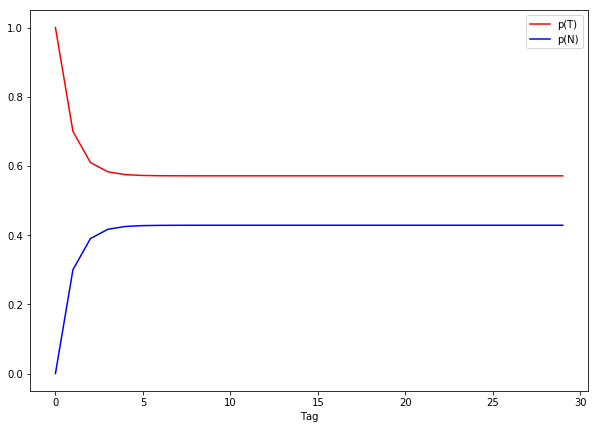

```python
n = 30
pi_k = pi_0
v_T = np.zeros(n)
v_N = np.zeros(n)

for k in range(n):
    v_T[k] = pi_k[0]
    v_N[k] = pi_k[1]
    pi_k = U.dot( pi_k )

print( "v_T = {}".format( v_T ) )
print( "v_N = {}".format( v_N ) )

import matplotlib.pyplot as plt
x = np.arange(0, n, 1)
plt.figure( figsize=(10,7) )
plt.plot( x, v_T, color="red", label="p(T)" )
plt.plot( x, v_N, color="blue", label="p(N)" )
plt.xlabel("Tag")
plt.legend()
plt.show()
```

### Teilaufgabe d) (optional, schwierig!)

Aus der Grafik ist ersichtlich, dass sich die Wahrscheinlichkeiten für trockene bzw. nasse Tage einem Grenzwert annähern. Versuchen Sie diese Grenzwerte mit einem Gleichungssystem zu berechnen. Gehen Sie dazu von der Überlegung aus, dass sich im Grenzustand bei $k=\infty$ nichts mehr verändert, d.h.

$$\pi_{k+1}=\pi_k=U\cdot\pi_k,$$

also

$$\pi_\infty=U\cdot\pi_\infty.$$

**Hinweis**: Diese Aufgabe werden Sie wahrscheinlich nicht nur mit `numpy` lösen können. Stellen Sie von Hand ein lineares Gleichungssystem auf und berechnen Sie dessen Lösung.

#### Lösung:

Setzen wir $\pi_\infty = \begin{pmatrix} x \\ y \end{pmatrix}$, so erhalten wir das folgende Gleichungssystem:

$$ \begin{eqnarray} 0.7x + 0.4y &=& x, \\ 0.3x + 0.6y &=& y, \end{eqnarray} $$

oder

$$ \begin{eqnarray} -0.3x + 0.4y &=& 0, \\ 0.3x - 0.4y &=& 0. \end{eqnarray} $$

Man sieht sofort, dass die zweite Zweile ein vielfaches der ersten Zeile ist und die erweiterte Koeffizientenmatrix nur den Rang 1 hat. Somit würden wir nur einen Raum mit unendlich vielen Lösungen erhalten.

Implizit haben wir aber angenommen, dass wir mit Wahrscheinlichkeiten rechnen. Die totale Wahrscheinlichkeit in $\pi_\infty$ sollte immer 1 sein, also können wir folgendes Gleichungssystem lösen:

$$ \begin{eqnarray} -0.3x + 0.4y &=& 0, \\ x + y &=& 1. \end{eqnarray} $$

mit `ǹp.linalg.solve()` bekommen wir:

```python
np.linalg.solve( np.array( [[-0.3,0.4],[1,1]] ), np.array( [[0],[1]] ) )
```

```
array([[0.57142857],
       [0.42857143]])
```